# 一种可编程的编程语言**A Programmable** **Programming** **Language**

**BY MATTHIAS FELLEISEN, ROBERT BRUCE FINDLER,** **MATTHEW FLATT, SHRIRAM KRISHNAMURTHI, ELI BARZILAY,** **JAY MCCARTHY, AND SAM TOBIN-HOCHSTADT**

软件行业正进入面向语言编程的时代，因此需要可编程的编程语言。As the software industry enters the era of language-oriented programming, it needs programmable programming languages.

**DOI:10.1145/3127323**

Communications of the ACM · March 2018 · Vol. 61 · No. 3 · pp. 62–71

原始 PDF · [DOI](https://doi.org/10.1145/3127323)Original PDF · [DOI](https://doi.org/10.1145/3127323)

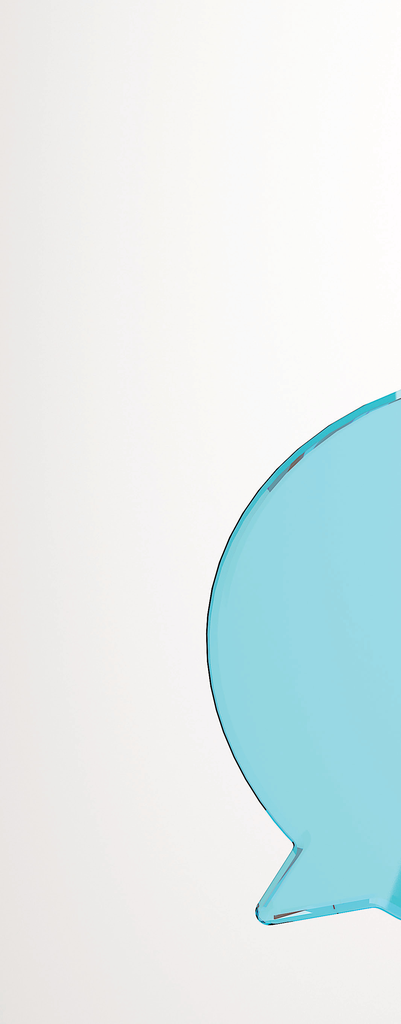

[figure not shown]

插图：CHRIS LABROOYILLUSTRATION BY CHRIS LABROOY

**在理想世界中**，软件开发者会用问题所属领域的语言分析每个问题，再用相应的术语表述解决方案。这样，他们就能轻松地与领域专家沟通，将问题本身的思想与通用语言的细节、具体的程序设计决策区分开来。**IN THE IDEAL** world, software developers would analyze each problem in the language of its domain and then articulate solutions in matching terms. They could thus easily communicate with domain experts and separate problem-specific ideas from the details of general-purpose languages and specific program design decisions.

然而在现实世界中，程序员使用的是别人为他们选定的主流编程语言。为解决这一矛盾，他们借助——有时也自行构建——嵌入在所选语言中的领域特定语言（embedded domain-specific languages，简称 eDSL）。例如，JavaScript 程序员使用 jQuery 与文档对象模型交互，用 React 处理事件与并发。In the real world, however, programmers use a mainstream programming language someone else picked for them. To address this conflict, they resort to—and on occasion build their own—domain-specific languages embedded in the chosen language (embedded domain-specific languages, or eDSLs). For example, JavaScript programmers employ jQuery for interacting with the Document Object Model and React for dealing with events and concurrency.

## 核心见解 **key insights**

面向语言编程是一种新兴的软件开发范式，有望彻底改变人们构建软件的方式。 **Language-oriented programming is** **an emerging software-development** **paradigm likely to revolutionize the way** **people build software.**

它把“语言”本身提升为软件构件，使其与对象、模块和组件具有同等地位。 **It elevates “language” itself to a software** **building block, with the same status as** **objects, modules, and components.**

与其他范式一样，面向语言编程在基础语言直接支持它时才能蓬勃发展；Racket 项目二十年来一直致力于支持面向语言编程，为深入探索这一令人振奋的新发展提供了平台。 **As with other paradigms, language** **orientation thrives when the base** **language supports it directly; the Racket** **project has worked on support for** **language-oriented programming for 20** **years, providing a platform for exploring** **this exciting new development in depth.**

开发者用合适的 eDSL 解决各个问题，再将这些解决方案组合成一个系统；也就是说，他们实际上是在一种共同的宿主语言中编写多语言软件。<sup>a</sup>As developers solve their problems in appropriate eDSLs, they compose these solutions into one system; that is, they effectively write multilingual software in a common host language.<sup>a</sup>

遗憾的是，如今的多语言 eDSL 编程主要依赖临时拼凑，十分繁琐。要创建和部署语言，程序员通常必须走出所选语言，设置配置文件、运行编译工具，并链接生成的目标代码文件。更糟的是，宿主语言无法支持对不同 eDSL 组件的适当、健全的集成。此外，多数现有集成开发环境（IDE）甚至无法理解 eDSL，也察觉不到用 eDSL 编写的代码。Sadly, multilingual eDSL programming is done today on an ad hoc basis and is rather cumbersome. To create and deploy a language, programmers usually must step outside the chosen language to set up configuration files and run compilation tools and link-in the resulting object-code files. Worse, the host languages fail to support the proper and sound integration of components in different eDSLs. Moreover, most available integrated development environments (IDEs) do not even understand eDSLs or perceive the presence of code written in eDSLs.

Racket 项目的目标，是从两个不同层面探索面向语言编程（language-oriented programming，简称 LOP）这一新兴思想。在实践层面，目标是构建一种支持面向语言软件设计的编程语言。它必须便于创建 eDSL，允许立即使用新建语言开发组件，并支持集成不同 eDSL 中的组件；Racket 可从 http://racket-lang.org/ 获取。The goal of the Racket project is to explore this emerging idea of language-oriented programming, or LOP, at two different levels. At the practical level, the goal is to build a programming language that enables language-oriented software design. This language must facilitate easy creation of eDSLs, immediate development of components in these newly created languages, and integration of components in distinct eDSLs; Racket is available at http://racket-lang.org/

在概念层面，支持 LOP 的理由，与支持面向对象编程和面向并发编程的理由类似。<sup>3</sup> 前者源于在语法上简便、在运行时低成本地创建和操作对象；后者源于 Erlang 低成本的进程创建和消息传递。这两项创新都带来了新的软件开发方式，并催生了研究项目。问题是，我们这一学科将如何实现 LOP，它又将怎样影响软件世界。At the conceptual level, the case for LOP is analogous to the ones for object-oriented programming and for concurrency-oriented programming.<sup>3</sup> The former arose from making the creation and manipulation of objects syntactically simple and dynamically cheap, the latter from Erlang’s inexpensive process creation and message passing. Both innovations enabled new ways to develop software and triggered research projects. The question is how our discipline will realize LOP and how it will affect the world of software.

我们决定开发一门新语言 Racket，部分出于历史原因，部分则因为我们希望在研究 LOP 时，摆脱工业界主流语言中一切不必要的约束。下一节将说明 Racket 的起源、我们如何逐渐聚焦于 LOP，以及 LOP 思想的含义。Our decision to develop a new language—Racket—is partly an historical artifact and partly due to our desire to free ourselves from any unnecessary constraints of industrial mainstream languages as we investigate LOP. The next section spells out how Racket got started, how we honed in on LOP, and what the idea of LOP implies.

## Racket 的原则**Principles of Racket**

Racket 项目始于 1995 年 1 月，最初用作试验教学用编程语言的平台。<sup>15</sup> 这项工作很快让我们认识到，语言本身就是解决问题的工具。不久，我们开始为项目的不同部分开发不同的语言：一种用于表述多种教学语言的（元）语言，一种用于定制 DrRacket IDE 的语言，<sup>15</sup> 以及一种用于管理配置的语言。最终，正如前文所述，这套软件成了一个多语言系统。The Racket project dates to January 1995 when we started it as a language for experimenting with pedagogic programming languages.<sup>15</sup> Working on them quickly taught us that a language itself is a problem-solving tool. We soon found ourselves developing different languages for different parts of the project: a (meta-) language for expressing many pedagogic languages, another for specializing the DrRacket IDE,<sup>15</sup> and a third for managing configurations. In the end, the software was a multilingual system, as outlined earlier.

Racket 的指导原则体现了这一认识：让程序员能够轻松创建新的编程语言，并以没有阻碍的过程将它们加入代码库。我们所说的“语言”，包含新的语法、静态语义，以及一种动态语义；动态语义通常将新语法映射到宿主语言的元素，也可能通过外部函数接口（FFI）映射到外部语言。具体例子见图 1：它展示了最近开发的一对视频编辑脚本语言<sup>2,b</sup>的架构，旨在帮助人们将会议演讲录像制作成 YouTube 视频与频道。其中大多数工作是重复性的——添加片头片尾、连接播放列表、叠加音频——只有少数步骤需要人工干预。这项任务需要一种领域特定脚本语言，而 `video` 正是满足这一需求的声明式 eDSL。Racket’s guiding principle reflects the insight we gained: empower programmers to create new programming languages easily and add them with a friction-free process to a codebase. By “language,” we mean a new syntax, a static semantics, and a dynamic semantics that usually maps the new syntax to elements of the host language and possibly external languages via a foreign-function interface (FFI). For a concrete example, see Figure 1 for a diagram of the architecture of a recently developed pair of scripting languages for video editing<sup>2,b</sup> designed to assist people who turn recordings of conference presentations into YouTube videos and channels. Most of that work is repetitive—adding preludes and postludes, concatenating playlists, and superimposing audio—with few steps demanding manual intervention. This task calls for a domain-specific scripting language; video is a declarative eDSL that meets this need.

图 1 一个小型的面向语言编程示例。Figure 1. Small language-oriented programming example.

[figure not shown]

`typed/video` 为 `video` 增加了类型系统。显然，类型系统领域也有自己的专业语言，因此 `typed/video` 的实现使用了 `turnstile`，<sup>6</sup> 这是一种专为表达类型系统创建的 eDSL。同样，实现 `video` 的渲染功能需要对多媒体框架进行绑定。我们的实现将绑定定义与 FFI 调用的重复细节分开，形成两部分：一种名为 `video/ffi` 的多媒体 FFI 领域特定语言，以及一个用该 eDSL 编写的程序。最后，为支持创建所有这些 eDSL，Racket 还提供了专门面向 eDSL 创建的 `syntax-parse` eDSL。<sup>7</sup>The `typed/video` language adds a type system to `video`. Clearly, the domain of type systems comes with its own language of expertise, and `typed/video`’s implementation thus uses `turnstile`,<sup>6</sup> an eDSL created for expressing type systems. Likewise, the implementation of `video`’s rendering facility calls for bindings to a multimedia framework. Ours separates the binding definitions from the repetitive details of FFI calls, yielding two parts: an eDSL for multimedia FFIs, dubbed `video/ffi`, and a single program in the eDSL. Finally, in support of creating all these eDSLs, Racket comes with the `syntax-parse` eDSL,<sup>7</sup> which targets eDSL creation.

LOP 原则还蕴含两条辅助准则：The LOP principle implies two subsidiary guidelines:

*让语言创建者能够强制执行语言的不变量。*编程语言是一种抽象，而抽象关乎完整性。例如，Java 提供内存安全性与类型健全性。当程序由不同语言编写的部分组成时，值会从一个上下文流向另一个上下文，需要保护它们免受可能破坏其完整性的操作影响，后文将进一步讨论；以及*Enable creators of a language to enforce its invariants.* A programming language is an abstraction, and abstractions are about integrity. Java, for example, comes with memory safety and type soundness. When a program consists of pieces in different languages, values flow from one context into another and need protection from operations that might violate their integrity, as we discuss later; and

*将语言之外的机制转化为语言构造。*LOP 程序员一旦求助于语言之外的机制，实际上就承认了所选语言缺乏表达能力。<sup>13,c</sup> 处理 Java 项目所需的众多外部语言——配置语言、项目描述语言和 `makefile` 语言——就是这一问题的症状。我们在本文后面将这些缺口视为有待解决的挑战。*Turn extra-linguistic mechanisms into* *linguistic constructs.* A LOP programmer who resorts to extra-linguistic mechanisms effectively acknowledges that the chosen language lacks expressive power.<sup>13,c</sup> The numerous external languages required to deal with Java projects—a configuration language, a project description language, and a `makefile` language—represent symptoms of this problem. We treat such gaps as challenges later in the article.

这些原则是在一个反馈循环中形成的；参与这一循环的包括 DrRacket，<sup>15</sup> 以及有类型语言、<sup>36</sup> 惰性语言<sup>4</sup>和教学语言。<sup>15</sup>They have been developed in a feedback loop that includes DrRacket<sup>15</sup> plus typed,<sup>36</sup> lazy,<sup>4</sup> and pedagogical languages.<sup>15</sup>

> 最值得注意的是，Racket 消除了库与语言之间的硬性边界，克服了一个看似难以调和的冲突。**Most notably,** **Racket eliminates** **the hard boundary** **between library** **and language,** **overcoming** **a seemingly** **intractable conflict.**

## 调和库与语言**Libraries and** **Languages Reconciled**

Racket 继承了 Lisp 和 Scheme。但与这些先辈不同，Racket 更强调函数式而非命令式编程，却不强制推行某种理念。Racket 不预设表层语法，甚至能够容纳传统语法的变体，例如 Algol 60。<sup>d</sup> 和许多语言一样，Racket 也是“开箱即用、配套齐全”的。Racket is an heir of Lisp and Scheme. Unlike these ancestors, however, Racket emphasizes functional over imperative programming without enforcing an ideology. Racket is agnostic when it comes to surface syntax, accommodating even conventional variants (such as Algol 60).<sup>d</sup> Like many languages, Racket comes with “batteries included.”

最值得注意的是，Racket 消除了库与语言之间的硬性边界，克服了一个看似难以调和的冲突。实践中，这意味着新的语言构造可以像库和包中的函数、类一样无缝导入。例如，Racket 的类系统和 `for` 循环都从普通库中导入，但多数程序员使用它们时，根本不会注意到这些其实是用户定义的概念。Most notably, Racket eliminates the hard boundary between library and language, overcoming a seemingly intractable conflict. In practice, this means new linguistic constructs are as seamlessly imported as functions and classes from libraries and packages. For example, Racket’s class system and `for` loops are imports from plain libraries, yet most programmers use these constructs without ever noticing their nature as user-defined concepts.

Racket 的关键创新是模块化语法系统。<sup>17,26</sup> 它改进了 Scheme 的宏系统，<sup>11,24,25</sup> 而 Scheme 宏系统又改进了 Lisp 的树变换系统。Racket 模块提供函数、类和语言构造等服务。为实现这些服务，模块可以请求其他模块的服务。在这个模块世界中，创建新语言只需创建一个提供语言服务的模块。这样的模块可以从基础语言中删去某些语言构造、重新解释另一些，再加入少量新构造。一门语言很少需要完全从零构建。Racket’s key innovation is a modular syntax system,<sup>17,26</sup> an improvement over Scheme’s macro system,<sup>11,24,25</sup> which in turn improved on Lisp’s tree-transformation system. A Racket module provides such services as functions, classes, and linguistic constructs. To implement them, a module may require the services of other modules. In this world of modules, creating a new language means simply creating a module that provides the services for a language. Such a module may subtract linguistic constructs from a base language, reinterpret others, and add a few new ones. A language is rarely built from scratch.

就像 Unix shell 脚本在第一行指定自己的方言一样，每个 Racket 模块也在第一行指定自己的语言。语言声明指向一个文件，其中包含定义语言的模块。只要创建这个文件，就完成了在 Racket 中构建的语言的安装。实际使用中，程序员可以在 IDE 的一个标签页中开发语言，另一个标签页中的模块则用前一标签页定义的语言编写。开发者不必离开 IDE 运行编译器、链接器或其他工具，就能修改第一个标签页中的语言实现，并立即在第二个标签页中看到修改的效果；也就是说，在 Racket 中，语言开发是一个没有阻碍的过程。Like Unix shell scripts, which specify their dialect on the first line, every Racket module specifies its language on the first line, too. This language specification refers to a file that contains a language-defining module. Creating this file is all it takes to install a language built in Racket. Practically speaking, a programmer may develop a language in one tab of the IDE, while another tab may be a module written in the language of the first. Without ever leaving the IDE to run compilers, linkers, or other tools, the developer can modify the language implementation in the first tab and immediately experience the modification in the second; that is, language development is a friction-free process in Racket.

在 shell 脚本的世界中，首行约定最终为许多 shell 替代语言打开了大门，包括 Perl、Python 和 Ruby。如今的 Racket 世界呈现出类似现象：语言库在生态中不断涌现，包括核心语言 `racket/base`、配套齐全的变体 `racket`，以及有类型变体 `typed/racket`。不太为人所知的例子还有 `datalog` 和一种 `web-server` 语言。<sup>27,30</sup> 需要精确区分时，我们用等宽字体写出小写语言名；否则只称“Racket”。In the world of shell scripts, the first-line convention eventually opened the door to a slew of alternatives to shells, including Perl, Python, and Ruby. The Racket world today reflects a similar phenomenon, with language libraries proliferating within its ecosystem: `racket/base`, the Racket core language; `racket`, the “batteries included” variant; and `typed/racket`, a typed variant. Some lesser-known examples are `datalog` and a `web-server` language.<sup>27,30</sup> When precision is needed, we use the lowercase name of the language in typewriter font; otherwise we use just “Racket.”

图 2 给出了一个示例模块。第一行读作“hash lang racket base”，表明模块使用 `racket/base` 编写。模块提供唯一的函数 `walk-simplex`。伴随的行注释以分号开头，非正式地给出了类型定义，以及根据该类型定义表述的函数签名；后文将展示如何用 `typed/racket` 将这些注释替换为静态检查的类型，如图 5 所示。为实现该函数，模块从图 3 概述的 `constraints` 模块导入功能。图 2 的最后三行勾勒出 `walk-simplex` 的定义，其中引用了从 `constraints` 导入的 `maximizer` 函数。Figure 2 is an illustrative module. Its first line—pronounced “hash lang racket base”—says it is written in `racket/base`. The module provides a single function, `walk-simplex`. The accompanying line comments—introduced with semicolons—informally state a type definition and a function signature in terms of this type definition; later, we show how developers can use `typed/racket` to replace such comments with statically checked types, as in Figure 5. To implement this function, the module imports functionality from the `constraints` module outlined in Figure 3. The last three lines of Figure 2 sketch the definition of the `walk-simplex` function, which refers to the `maximizer` function imported from constraints.

图 2 一个普通的 Racket 模块。Figure 2. A plain Racket module.

类型 `MaxPath` 是边的列表；`walk-simplex` 从自然数映射到 `MaxPath`。type MaxPath = [Listof Edge]; Natural → MaxPath

`demo`

```
#lang racket/base
(provide
  ;; type MaxPath = [Listof Edge]
  ;; Natural -> MaxPath
  walk-simplex)

(require "constraints" graph)

;; Natural -> MaxPath
(define (walk-simplex timing)
  ... (maximizer #:x 2)...)
```

图 3 中的 `"constraints"` 模块用领域特定语言表达其唯一服务的实现，因为它处理的是单纯形，而单纯形天然适合用不等式组表达。模块使用的 `simplex` 语言从 `racket/base` 继承了行注释语法，其余部分则采用中缀语法。如注释所述，模块导出一个函数 `maximizer`，它接收两个可选的关键字参数。像图 2 那样，以 `(maximizer #:x n)` 调用时，它会给出该约束系统中最大的 `y` 值。如图 3 下半部分所示，这些约束使用传统语法指定。The `"constraints"` module in Figure 3 expresses the implementation of its only service in a domain-specific language because it deals with simplexes, which are naturally expressed through a system of inequalities. The module’s `simplex` language inherits the line-comment syntax from `racket/base` but uses infix syntax otherwise. As the comments state, the module exports a single function, `maximizer`, which consumes two optional keyword parameters. When called as (`maximizer` `#:x` `n`), as in Figure 2, it produces the maximal `y` value of the system of constraints. As in the lower half of Figure 3, these constraints are specified with conventional syntax.

图 3 一个描述单纯形形状的模块。Figure 3. A module for describing a simplex shape.

隐式提供合成的函数 `maximizer`；关键字参数 `#:x` 或 `#:y` 接收实数，并返回实数。implicitly provides synthesized function maximizer: #:x Real → Real; #:y Real → Real

`constraints`

```
#lang simplex

;; implicitly provides synthesized function maximizer:
;;   #:x Real -> Real
;;   #:y Real -> Real

#:variables x y

3 * x + 5 * y <= 10
3 * x - 5 * y <= 20
```

为支持这类编程，Racket 的模块化语法系统引入了若干关键创新。其中一个尤其能说明问题：通过模块系统，增量地重新定义现有语言构造的含义。eDSL 创建者可以复用熟悉的语法、赋予其新的解释，从而让用户平缓地进入新语言。In support of this kind of programming, Racket’s modular syntax system benefits from several key innovations. A particularly illustrative one is the ability to incrementally redefine the meaning of existing language constructs via the module system. It allows eDSL creators to ease their users into a new language by reusing familiar syntax, but reinterpreted.

以 `lambda` 表达式为例。假设开发者希望为某种脚本语言（例如 `video`）配备能够检查参数是否满足指定谓词的函数。图 4 展示了基本思路：Consider `lambda` expressions, for example. Suppose a developer wishes to equip a scripting language (such as `video`) with functions that check whether their arguments satisfy specified predicates. Figure 4 shows the basic idea:

图 4 重新定义 lambda。Figure 4. Lambda, redefined.

`new-lam`

```
#lang racket

(provide (rename-out [new-lambda lambda]))

(require (for-syntax syntax/parse))
...
;; Syntax -> Syntax
(define-syntax (new-lambda stx)
 (syntax-parse stx
  [(new-lambda (x:id (~literal ::) predicate:id) body:expr)
    (syntax
     (lambda (x)
       (unless (predicate x)
         (define name (object-name predicate))
         (error 'lambda "~a expected, given: ~e" name x))
       body))]))
...
```

*第 01 行：*模块使用 `racket` 语言。*line 01* The module uses the `racket` language.

*第 03 行：*它将定义的编译期函数 `new-lambda` 以 `lambda` 为名导出。代码中的上划线表明，这个名称来自本模块。*line 03* It exports a defined compile-time function, `new-lambda`, under the name `lambda`, which is overlined in the code to mark its origin as this module.

*第 05 行：*模块从一个库中导入工具，以便方便地创建健壮的编译期函数。<sup>7</sup>*line 05* Here, the module imports tools from a library for creating robust compile-time functions conveniently.<sup>7</sup>

*第 07 行：*注释说明，下面是一个作用于语法树的函数。*line 07* The comment says a function on syntax trees follows.

*第 08 行：*`(define (f x) ...)` 引入以 `x` 为参数的普通函数 `f`；而 `(define-syntax (c stx) ...)` 则创建接收单个参数 `stx` 的编译期函数 `c`。*line 08* While (`define` `(f` `x)` `.` `.` `.` ) introduces an ordinary function `f` of `x`, (`define-syntax` `(c` `stx)` `.` `.` `.` ) creates the compile-time function `c` with a single argument, `stx`.

*第 09 行：*与许多函数式语言一样，Racket 提供模式匹配构造。这里使用前述库中的 `syntax-parse`。第一部分指定待匹配的树（`stx`），其余部分则给出一系列“模式—响应”子句。*line 09* As with many functional languages, Racket comes with pattern-matching constructs. This one uses `syntax-parse` from the library mentioned earlier. Its first piece specifies the to-be-matched tree (`stx`); the remainder specifies a series of pattern-responses clauses.

*第 10 行：*这个模式匹配首个词元为 `new-lambda`、其后跟着参数说明和函数体的语法树。注解 `:id` 要求模式变量 `x` 和 `predicate` 在各自位置上只能匹配标识符。同样，`:expr` 要求 `body` 模式变量只能匹配表达式。*line 10* This pattern matches any syntax tree with first token as `new-lambda` followed by a parameter specification and a body. The annotation `:id` demands that the pattern variables `x` and `predicate` match only identifiers in the respective positions. Likewise, `:expr` allows only expressions to match the body pattern variable.

*第 11 行：*编译期函数通过 `syntax` 合成新的树。*line 11* A compile-time function synthesizes new trees with `syntax`.

*第 12 行：*生成的语法树是一个 `lambda` 表达式。具体来说，函数生成了使用 `lambda` 的表达式。代码中的下划线表明，这个名称来自环境语言，此处即 `racket`。*line 12* The generated syntax tree is a `lambda` expression. Specifically, the function generates an expression that uses `lambda`. The underline in the code marks its origin as the ambient language, here `racket`.

*其余各行：*语法系统遇到模式变量 `x`、`predicate` 和 `body` 时，会分别插入与它们匹配的子树。*other lines* Wherever the syntax system encounters the pattern variables `x`, `predicate`, and `body`, it inserts the respective subtrees that match x, predicate, and body.

当另一个模块使用 `"new-lam"` 作为语言时，编译器会按如下过程，将表层语法细化为核心语言：When another module uses `“new-lam”` as its language, the compiler elaborates the surface syntax into the core language like this

```
(lambda (x :: integer?) (+ x 1))
```

↓ 细化为↓ elaborates to

[output not shown]

↓ 细化为↓ elaborates to

```
(new-lambda (x :: integer?) (+ x 1))
```

↓ 细化为↓ elaborates to

```
(lambda (x)
  (unless (integer? x)
    <elided error reporting>)
  (+ x 1))
```

第一步将 `lambda` 解析为它所导入的含义，<sup>18</sup> 即带上划线的 `lambda`。第二步反向执行“导出时重命名”的指令。最后，编译期函数 `new-lambda` 将给定语法树转换为一个 `racket` 函数。The first elaboration step resolves `lambda` to its imported meaning,<sup>18</sup> or `lambda`. The second reverses the “rename on export” instruction. Finally, the `new-lambda` compile-time function translates the given syntax tree into a `racket` function.

本质上，图 4 为单参数函数实现了一个简单的前置条件系统。接下来，语言开发者可能希望引入多参数 `lambda` 表达式、增加指定后置条件的位置，或让注解变为可选。自然，也可以修改编译期函数，对部分或全部注解进行静态检查，最终得到一种类似 `typed/racket` 的语言。In essence, Figure 4 implements a simplistic precondition system for one-argument functions. Next, the language developer might wish to introduce multiargument `lambda` expressions, add a position for specifying the post-condition, or make the annotations optional. Naturally, the compile-time functions could then be modified to check some or all of these annotations statically, eventually resulting in a language that resembles `typed/racket`.

## 语言之间的健全协作**Sound Cooperation** **Between Languages**

基于 LOP 的软件系统由多个协同工作的组件组成，各组件用领域特定语言编写。“协作”意味着组件交换值，而“多种语言”意味着这些值在不同语言中创建。在这种情形下，很容易出问题，图 5 用一个小例子作了演示。左侧是用 `typed/racket` 编写的模块，导出一个数值微分函数；右侧是用 `racket` 编写的模块，导入该函数，并以三种不同方式应用它，全部不合法。如果这些非法用法没有被发现，开发者就无法依靠类型信息设计函数或调试，编译器也无法依靠类型信息进行优化。总体而言，相互协作的多语言组件，必须遵守各参与语言所建立的不变量。A LOP-based software system consists of multiple cooperating components, each written in domain-specific languages. Cooperation means the components exchange values, while “multiple languages” implies these values are created in distinct languages. In this setting, things can easily go wrong, as demonstrated in Figure 5 with a toy scenario. On the left, a module written in `typed/racket` exports a numeric differentiation function. On the right, a module written in `racket` imports this function and applies it in three different ways, all illegal. If such illegal uses of the function were to go undiscovered, developers would not be able to rely on type information for designing functions or for debugging, nor could compilers rely on them for optimizations. In general, cooperating multilingual components must respect the invariants established by each participating language.

图 5 保护不变量。Figure 5. Protecting invariants.

右侧模块依次展示情形 1、情形 2 和情形 3。scenario 1; scenario 2; scenario 3

`TR`

```
#lang typed/racket

(provide diff)

(: diff
   ((Real -> Real)
    ->
    (Real -> Real)))
(define (diff f)
  (lambda (x)
    (define lo (f (- x eps)))
    (define hi (f (+ x eps)))
    (/ (- hi lo)
       (* 2 eps))))
```

`RR`

```
#lang racket

(require "TR.rkt")

;; scenario 1
(diff 1)
;; scenario 2
(define (f-bool x)
  #true)
(diff f-bool)
;; scenario 3
(define (f-char x)
  (string x))
(diff f-str)
```

> 总体而言，相互协作的多语言组件，必须遵守各参与语言所建立的不变量。**In general,** **cooperating** **multilingual** **components** **must respect** **the invariants** **established by** **each participating** **language.**

现实中的编程语言对不变量提供的保证，构成一个不同程度健全性的谱系。例如，C++ 不健全。运行中的 C++ 程序可以对任意比特模式应用任意操作；只要硬件不反对，程序就继续执行。错误解释这些比特之后，程序甚至可能“正常”结束，打印出各种输出。相比之下，Java 不允许错误表示比特，但也只比 C++ 稍微健全一些。<sup>1</sup> ML 又优于 Java，具有完全的健全性，不会有任何值被不适当的操作处理。In the real world, programming languages satisfy a spectrum of guarantees about invariants. For example, C++ is unsound. A running C++ program may apply any operation to any bit pattern and, as long as the hardware does not object, program execution continues. The program may even terminate “normally,” printing all kinds of output after the misinterpretation of the bits. In contrast, Java does not allow the misrepresentation of bits but is only somewhat more sound than C++.<sup>1</sup> ML improves on Java again and is completely sound, with no value ever manipulated by an inappropriate operation.

Racket 希望在两个层面反映这一健全性谱系：语言实现本身，以及用不同嵌入式语言编写的两个组件之间的协作。先考虑语言的健全性。正如领域特定语言文献所指出的，<sup>20</sup> 这类语言往往沿特定方式演进，Racket 世界也如此，见图 6。第一个实现往往只是高效 C 级 API 外的一层薄包装。Racket 开发者使用允许带括号的 C 级编程的外部接口创建这层包装。<sup>5</sup> 程序员可以引用 C 库、导入函数和数据结构，再将这些导入项包装成 Racket 值。图 7 以模块草图说明了这一思路；`video` 的最初实现，正是对视频渲染框架的一组这样的绑定。当 `racket/base` 模块导入 `ffi/unsafe` 库时，该模块的语言是不健全的。Racket aims to mirror this spectrum of soundness at two levels: language implementation itself and cooperation between two components written in different embedded languages. First consider the soundness of languages. As the literature on domain-specific languages suggests,<sup>20</sup> such languages normally evolve in a particular manner, as is true for the Racket world, as in Figure 6. A first implementation is often a thin veneer over an efficient C-level API. Racket developers create such a veneer with a foreign interface that allows parenthesized C-level programming.<sup>5</sup> Programmers can refer to a C library, import functions and data structures, and wrap these imports in Racket values. Figure 7 illustrates the idea with a sketch of a module; `video`’s initial implementation consisted of just such a set of bindings to a video-rendering framework. When a `racket/base` module imports the `ffi/unsafe` library, the language of the module is unsound.

图 6 逐步加固一个模块。Figure 6. Hardening a module.

含 `ffi/unsafe` 的 `racket/base``racket/base` with `ffi/unsafe`

加固 ↓harden ↓

`racket/base``racket/base`

加固 ↓harden ↓

带契约的 `racket/base``racket/base` with contracts

加固 ↓harden ↓

`typed/racket``typed/racket`

图 7 使用外部函数接口的 Racket 模块。Figure 7. A Racket module using the foreign-function interface.

`ffi`

```
#lang racket/base

(provide
 ;; [Vectorof [Vectorof Real]] -> [Vectorof Real]
 simplex)

(require ffi/unsafe)

(define (simplex M)
  ... (ffi-simplex-set ...) ...)

(define lib-simplex (ffi-lib "./coin-Clp/lib/libClp"))

(define ffi-simplex-set
  (get-ffi-obj "simplex" lib-simplex (_fun _bytes -> _void)))
```

语言开发者从不健全的 eDSL 起步后，紧接着很可能就会使其变得健全。为此，可以为语言加入类似动态类型脚本语言的运行期检查，防止不合适的值流向不健全的原语。遗憾的是，这种保护是临时拼凑的；除非开发者极为细心，否则错误信息可能来自库内部，将错误归咎于某个 `racket/base` 原语操作。为解决这一问题，Racket 提供了高阶契约，<sup>16</sup> 使语言开发者能够统一保护库的 API，阻挡不合适的值。例如，`video/ffi` 提供语言构造，使视频渲染框架的绑定变得安全。除了普通逻辑断言，Racket 开发者还在试验用于检查协议、尤其是时序协议的契约。<sup>9</sup> 契约库内置的归责机制保证归责分配的健全性。<sup>10</sup>A language developer who starts with an unsound eDSL is likely to make it sound as the immediate next step. To this end, the language is equipped with runtime checks similar to those found in dynamically typed scripting languages to prevent the flow of bad values to unsound primitives. Unfortunately, such protection is ad hoc, and, unless developers are hypersensitive, the error messages may originate from inside the library, thus blaming some `racket/base` primitive operation for the error. To address this problem, Racket comes with higher-order contracts<sup>16</sup> with which a language developer might uniformly protect the API of a library from bad values. For example, the `video/ffi` language provides language constructs for making the bindings to the video-rendering framework safe. In addition to plain logical assertions, Racket’s developers are also experimenting with contracts for checking protocols, especially temporal ones.<sup>9</sup> The built-in blame mechanism of the contract library ensures sound blame assignment.<sup>10</sup>

最后，语言开发者可能希望在程序运行*之前*，就检查某些逻辑不变量。简单类型检查是一个例子，也可以进行其他形式的静态检查。`typed/video` 展示了这一点：它的类型系统检查函数的输入和输出类型，而这些类型可以包含对整数参数的数值约束；因此，任何脚本都不可能渲染出长度为负的视频。同样，`typed/racket` 是 `racket`（大部分功能）的有类型变体。Finally, a language developer may wish to check some logical invariants *before* the programs run. Checking simple types is one example, though other forms of static checking are also possible. The `typed/video` language illustrates this point with a type system that checks the input and output types of functions that may include numeric constraints on the integer arguments; as a result, no script can possibly render a video of negative length. Likewise, `typed/racket` is a typed variant of (most of) racket.

再考虑相互协作的语言的健全性。语言开发者同样需要预见本语言中的程序将如何与其他程序交互。例如，`typed/video` 的创建者没有为其程序提供保护。相比之下，`typed/racket` 的创建者原本就希望它用于多语言环境，因此它会将导出函数的类型编译为前文所述的高阶契约。比如，当导出的函数必须始终应用于整数值时，生成的契约会插入检查，在该函数的每个应用点确保实参的“整数性”；函数已经经过静态类型检查，因此无须在其返回点插入这类检查。对于接收整数值函数作为参数的函数，契约必须确保传入的函数始终返回整数。一般来说，契约通过代理<sup>31</sup>包装导出的值，控制对值的访问。这一思想源于 Matthews 和 Findler，<sup>29</sup> 而 Tobin-Hochstadt 与 Felleisen 的归责定理<sup>35</sup>表明：这样的混合系统一旦出错，运行期异常会将两个出错组件及其边界指出为问题来源。<sup>10</sup> 总体而言，Racket 提供了一系列保护机制，语言创建者可用它们为协作的 eDSL 实现不同程度的健全性保证。Now consider the soundness of cooperating languages. It is again up to the language developer to anticipate how programs in this language interact with others. For example, the creator of `typed/video` provides no protection for its programs. In contrast, the creators of `typed/racket` intended the language to be used in a multilingual context; `typed/racket` thus compiles the types of exported functions into the higher-order contracts mentioned. When, for example, an exported function must always be applied to integer values, the generated contract inserts a check that ensures the “integerness” of the argument at every application site for this function; there is no need to insert such a check for the function’s return points because the function is statically type checked. For a function that consumes an integer-valued function, the contract must ensure the function argument always returns an integer. In general, a contract wraps exported values with a proxy<sup>31</sup> that controls access to the value. The idea is due to Matthews and Findler,<sup>29</sup> while Tobin-Hochstadt’s and Felleisen’s Blame Theorem<sup>35</sup> showed that if something goes wrong with such a mixed system, the runtime exception points to two faulty components and their boundary as the source of the problem.<sup>10</sup> In general, Racket supplies a range of protection mechanisms, and a language creator can use them to implement a range of soundness guarantees for cooperating eDSLs.

## 通用计算能力与表达能力**Universality vs. Expressiveness**

一种通用语言能够计算所有偏递归函数，并不意味着程序员一定能用它表达自己关于程序的全部想法。<sup>13</sup> 用一个例子最容易说明这一点。设想要用某门新编程语言本身，为它构建 IDE。像任何现代 IDE 一样，它应当允许用户编译、运行代码。如果代码进入无限循环，用户必须能够轻点鼠标就将其终止。要以自然的方式<sup>e</sup>实现这一能力，语言必须将可控进程——线程——这一概念内化。如果没有内化这样的概念，IDE 的实现者就必须走出语言，设法复用底层操作系统的进程。Just because a general-purpose language can compute all partial-recursive functions, programmers cannot necessarily express all their ideas about programs in this language.<sup>13</sup> This point is best illustrated through an example. So, imagine the challenge of building an IDE for a new programming language in the very same language. Like any modern IDE, it is supposed to enable users to compile and run their code. If the code goes into an infinite loop, the user must be able to terminate it with a simple mouse click. To implement this capability in a natural<sup>e</sup> manner, the language must internalize the idea of a controllable process, a thread. If it does not internalize such a notion, the implementer of the IDE must step outside the language and somehow re-use processes from the underlying operating system.

对编程语言研究者来说，“走出语言”意味着失败。或者，用 Ingalls 的话说，<sup>21</sup>“操作系统是一堆无法放进语言里的东西；它本不该存在。”作为 Racket 的创建者，我们一直在识别 Racket 从周围操作系统借用的服务，并将其吸收到语言本身之中。<sup>19</sup> 以下三个示例构造，曾经要求程序员走出 Racket，现在则不必了：For a programming language researcher, “stepping outside the language” signals failure. Or, as Ingalls<sup>21</sup> said, “[an] operating system is a collection of things that don’t fit into a language[; t]here shouldn’t be one.” We, Racket creators, have sought to identify services Racket borrows from the surrounding operating system and assimilate them into the language itself.<sup>19</sup> Here are three sample constructs for which programmers used to step outside of Racket but no longer need to:

*沙箱（sandbox）：*限制对资源的访问；*Sandboxes.* That restrict access to resources;

*检查器（inspector）：*控制反射能力；以及*Inspectors.* That control reflective capabilities; and

*资源管理器（custodian）：*管理线程、套接字等资源。*Custodians.* That manage resources (such as threads and sockets).

要理解把这些服务纳入语言如何帮助语言设计者，可以看看 2014 年的 `shill` 语言。<sup>32</sup> 大体而言，`shill` 是 Racket 生态中的一种安全脚本语言。开发者可用它表述细粒度的安全策略和资源策略，例如函数可以访问哪些文件、脚本可以运行哪些二进制程序，由语言确保这些约束得到满足。具体而言，设想一个允许学生提交程序的作业服务器。教师可能希望对所有提交运行自动评分进程。使用 `shill` 脚本，服务器就能执行学生程序，而这些程序无法成功攻击服务器、在文件系统中搜寻答案，或借助外部连接窃取其他学生的答案。自然，`shill` 的实现大量使用 Racket 的沙箱执行机制，以及通过 custodian 回收资源的机制。To understand how inclusion of such services helps language designers, consider a 2014 example, the `shill` language.<sup>32</sup> Roughly speaking, `shill` is a secure scripting language in Racket’s ecosystem. With `shill`, a developer articulates fine-grain security and resource policies—along with, say, what files a function may access or what binaries the script may run—and the language ensures these constraints are satisfied. To make this concrete, consider a homework server to which students can submit their programs. The instructor might wish to run an autograde process for all submissions. Using a `shill` script, the homework server can execute student programs that cannot successfully attack the server, poke around in the file system for solutions, or access external connections to steal other students’ solutions. Naturally, `shill`’s implementation makes extensive use of Racket’s means of running code in sandboxes and harvesting resources via custodians.

> Racket 借用周围操作系统提供的服务，并将这些语言之外的机制吸收到语言本身之中。**Racket borrows** **from the** **surrounding** **operating system** **and assimilates** **such extra-linguistic** **mechanisms into** **the language itself.**

## 现状**State of Affairs**

前面各节说明了 Racket 如何使程序员能够做到以下几点：The preceding sections explained how Racket enables programmers to do the following:

*创建语言：*通过语言层面的复用，为具体任务和问题的不同方面创建语言；*Create languages.* Create by way of linguistic reuse for specific tasks and aspects of a problem;

*赋予健全性：*为语言赋予普通语言实现中几乎任何一种常见程度的健全性；以及*Equip with soundness.* Equip a language with almost any conventional level of soundness, as found in ordinary language implementations; and

*利用服务：*利用多种已经内化的操作系统服务，为这些嵌入式语言构建运行时库。*Exploit services.* Exploit a variety of internalized operating system services for constructing runtime libraries for these embedded languages.

使这类面向语言编程得以运作的，是“增量性”，即把语言拆成小块、逐步开发的能力。如果不要求传统语法，开发者就可以每次添加一个构造，在旧语言的基础上创建新语言。同样，他们不必一次性交付健全且安全的产品；可以先给现有的 C 级库加一层包装来创建语言，逐步从接口中提炼出更多语言特征，再根据时间条件或日益增长的用户需求，提高语言的健全性或安全性。What makes such language-oriented programming work is “incrementality,” or the ability to develop languages in small pieces, step by step. If conventional syntax is not a concern, developers can create new languages from old ones, one construct at a time. Likewise, they do not have to deliver a sound and secure product all at once; they can thus create a new language as a wrapper around, say, an existing C-level library, gradually tease out more of the language from the interface, and make the language as sound or secure as time permits or a growing user base demands.

此外，整个过程都发生在 Racket 生态中。开发者将语言创建为 Racket 模块，再把它“导入”另一个模块，便完成了安装。这种紧密结合有两个含义：生态中的开发工具既能用于创建语言模块，也能用于创建它们的客户端；而新语言又可以用来创建更多语言。大型项目常常使用由数十种语言构成的语言塔，共同管理现代软件系统中令人望而生畏的复杂性。Moreover, the entire process takes place within the Racket ecosystem. A developer creates a language as a Racket module and installs it by “importing” it into another module. This tight coupling has two implications: the development tools of the ecosystem can be used for creating language modules and their clients; and the language becomes available for creating more languages. Large projects often employ a tower involving a few dozen languages, all helping manage the daunting complexity in modern software systems.

索尼的 *Naughty Dog* 游戏工作室就创建了这样一个大型项目——实际上是一个用于创建项目的框架。大体而言，索尼基于 Racket 的架构提供了描述场景、场景间过渡、场景配乐等内容的语言。领域专家用这些语言描述游戏的不同方面。Racket 实现将这些领域特定程序组合起来，再编译成动态链接库，供基于 C 的游戏引擎使用；图 8 直观勾勒了这一安排。Sony’s *Naughty Dog* game studio has created just such a large project, actually a framework for creating projects. Roughly speaking, Sony’s Racket-based architecture provides languages for describing scenes, transitions between scenes, scores for scenes, and more. Domain specialists use the languages to describe aspects of the game. The Racket implementation composes these domain-specific programs, then compiles them into dynamically linked libraries for a C-based game engine; Figure 8 sketches the arrangement graphically.

图 8 面向语言编程的一个工业实例概览。Figure 8. A sketch of an industrial example of language-oriented programming.

[figure not shown]

Racket 的面向语言编程方案绝非完美。首先，判断一个库何时应当成为语言，需要敏锐的判断力。接下来，还必须在语言构造、语法和运行期原语方面作出良好选择。Racket’s approach to language-oriented programming is by no means perfect. To start with, recognizing when a library should become a language requires a discriminating judgment call. The next steps require good choices in terms of linguistic constructs, syntax, and runtime primitives.

就具体语法而言，Racket 目前有力地支持典型的、增量式的 Lisp 风格语法开发，也提供了生成词法分析器和语法分析器等对传统语法的常规支持。虽然传统语法分析自然地实现了前文所说的表层语法与含义的分离，但它也意味着开发过程不再具有增量性。恰当的解决办法，应当是把 Racket 的思想引入一个以传统语法为默认选择的环境。<sup>f</sup>As for concrete syntax, Racket currently has strong support for typical, incremental Lisp-style syntax development, including traditional support for conventional syntax, or generating lexers and parsers. While traditional parsing introduces the natural separation between surface syntax and meaning mentioned earlier, it also means the development process is no longer incremental. The proper solution would be to inject Racket ideas into a context where conventional syntax is the default.<sup>f</sup>

就静态检查而言，Racket 迫使语言设计者完整地开发检查器，而不能增量开发。例如，`typed/racket` 的类型检查器，与任何传统有类型语言的类型检查器相似：它是一个完整的递归下降算法，遍历模块的表示，并以代数方式检查类型。Racket 开发者真正想要的是一种将类型检查规则附着到语言构造上的方法，使这类算法能够按需合成。As for static checking, Racket forces language designers to develop such checkers wholesale, not incrementally. The type checker for `typed/racket` looks like, for example, the type checker for any conventionally typed language; it is a complete recursive-descent algorithm that traverses the module’s representation and algebraically checks types. What Racket developers really want is a way to attach type-checking rules to linguistic constructs, so such algorithms can be synthesized as needed.

Chang 等人<sup>6</sup>或许已经朝解决这一问题迈出了第一步；迄今，他们展示了如何以增量、模块化的方式，为 DSL 配备任意遵循结构规则的类型系统。一个完全通用的解决方案，还必须处理子结构类型系统（例如 Rust 编程语言所采用的），以及静态程序分析（例如大多数编译器中的分析）。Chang et al.<sup>6</sup> probably took a first step toward a solution for this problem and have thus far demonstrated how their approach can equip a DSL with any structural type system in an incremental and modular manner. A fully general solution must also cope with substructural type systems (such as the Rust programming language) and static program analyses (such as those found in most compilers).

就动态检查而言，Racket 有两个显著局限。一方面，它提供了使语言协作保持健全的基本构件，但开发者必须临时搭建所需的健全性保障框架。为方便组合不同语言中的组件，Racket 开发者既需要理论框架，也需要能够部分自动化这一任务的抽象。另一方面，现有健全性机制谱系的两端都缺乏足够能力，而且尚不清楚如何无缝整合这些能力。要完全控制自身所处的环境，Racket 可能需要访问所有平台上的汇编语言，从硬件直到浏览器。要充分发挥类型的力量，`typed/racket` 必须配备依赖类型。例如，当 Racket 程序使用向量时，对应的有类型变体会检查写入和读出的值，但与 ML 或 Haskell 一样，索引仍交由运行时系统中的（契约）检查处理。Tobin-Hochstadt 及其 Typed Racket 团队正朝这一方向迈出第一步，重点关注数值约束，<sup>23</sup> 类似于 Xi 和 Pfenning 的研究。<sup>37</sup>As for dynamic checking, Racket suffers from two notable limitations: On one hand, it provides the building blocks for making language cooperation sound, but developers must create the necessary soundness harnesses on an ad hoc basis. To facilitate the composition of components in different languages, Racket developers need both a theoretical framework and abstractions for the partial automation of this task. On the other hand, the available spectrum of soundness mechanisms lacks power at both ends, and how to integrate these powers seamlessly is unclear. To achieve full control over its context, Racket probably needs access to assembly languages on all possible platforms, from hardware to browsers. To realize the full power of types, `typed/racket` will have to be equipped with dependent types. For example, when a Racket program uses vectors, its corresponding typed variant type-checks what goes into them and what comes out, but like ML or Haskell, indexing is left to a (contractual) check in the runtime system. Tobin-Hochstadt and his Typed Racket group are working on first steps in this direction, focusing on numeric constraints,<sup>23</sup> similar to Xi’s and Pfenning’s research.<sup>37</sup>

> 要完全控制自身所处的环境，Racket 可能需要访问所有平台上的汇编语言，从硬件直到浏览器。**To achieve full** **control over its** **context, Racket** **probably needs** **access to assembly** **languages on all** **possible platforms,** **from hardware to** **browsers.**

就安全而言，Racket 项目仍在寻求重大突破。尽管 `shill` 团队能够在 Racket 生态内部构建该语言，但他们的工作暴露出：Racket 的面向语言编程原则，与它执行安全策略的方式之间，存在严重缺口。因此，团队不得不修改 Racket 的许多安全机制，并发明新的机制。显然，Racket 必须大幅降低这一步的难度，也就是说，还需要更多研究，才能使安全成为语言创建不可分割的一部分。As for security, the Racket project is still looking for a significant breakthrough. While the `shill` team was able to construct the language inside the Racket ecosystem, its work exposed serious gaps between Racket’s principle of language-oriented programming and its approach to enforcing security policies. It thus had to alter many of Racket’s security mechanisms and invent new ones. Racket must clearly make this step much easier, meaning more research is needed to turn security into an integral part of language creation.

最后，LOP 也给工具构建者带来了全新挑战。IDE 通常针对单门语言或一组相关语言提供工具，包括调试器、跟踪器和性能分析器。好的工具会用源语言的术语与开发者交流。LOP 的本性要求将这类工具定制到多种语言，以及它们各自的抽象和不变量上。我们在构建用于调试 `syntax` 语言程序的工具方面已取得部分成功，<sup>8</sup> 奠定了调试框架的基础，<sup>28</sup> 并开始探索如何推断新引入的语言级抽象的作用域规则和高层语义。<sup>33,34</sup> 如何自动将这些工具定制到新创建的语言及其组合上，仍是一个开放挑战。Finally, LOP also poses brand-new challenges for tool builders. An IDE typically provides tools for a single programming language or a family of related languages, including debuggers, tracers, and profilers. Good tools communicate with developers in terms of the source language. Due to its very nature, LOP calls for customization of such tools to many languages, along with their abstractions and invariants. We have partially succeeded in building a tool for debugging programs in the syntax language,<sup>8</sup> have the foundations of a debugging framework,<sup>28</sup> and started to explore how to infer scoping rules and high-level semantics for newly introduced, language-level abstractions.<sup>33,34</sup> Customizing these tools automatically to newly created (combinations of) languages remains an open challenge.

## 结论**Conclusion**

编程语言研究尚未实现其终极目标：为软件开发者提供工具，使他们能够用问题领域的语言表述解决方案。Racket 是继续探索恰当语言抽象的一次尝试。虽然它在这一方向上取得了显著成功，但也表明，在面向语言编程的愿景成为现实之前，编程语言研究还有许多问题需要解决。Programming language research is short of its ultimate goal—provide software developers tools for formulating solutions in the languages of problem domains. Racket is one attempt to continue the search for proper linguistic abstractions. While it has achieved remarkable success in this direction, it also shows that programming-language research has many problems to address before the vision of language-oriented programming becomes reality.

## 致谢**Acknowledgments**

感谢 Claire Alvis、Robert Cartwright、Ryan Culpepper、John Clements、Stephen Chang、Richard Cobbe、Greg Cooper、Christos Dimoulas、Bruce Duba、Carl Eastlund、Burke Fetscher、Cormac Flanagan、Kathi Fisler、Dan Friedman、Tony Garnock Jones、Paul Graunke、Dan Grossman、Kathy Gray、Casey Klein、Eugene Kohlbecker、Guillaume Marceau、Jacob Matthews、Scott Owens、Greg Pettyjohn、Jon Rafkind、Vincent St-Amour、Paul Steckler、Stevie Strickland、James Swaine、Asumu Takikawa、Kevin Tew、Neil Toronto 和 Adam Wick 作出的贡献。We thank Claire Alvis, Robert Cartwright, Ryan Culpepper, John Clements, Stephen Chang, Richard Cobbe, Greg Cooper, Christos Dimoulas, Bruce Duba, Carl Eastlund, Burke Fetscher, Cormac Flanagan, Kathi Fisler, Dan Friedman, Tony Garnock Jones, Paul Graunke, Dan Grossman, Kathy Gray, Casey Klein, Eugene Kohlbecker, Guillaume Marceau, Jacob Matthews, Scott Owens, Greg Pettyjohn, Jon Rafkind, Vincent St-Amour, Paul Steckler, Stevie Strickland, James Swaine, Asumu Takikawa, Kevin Tew, Neil Toronto, and Adam Wick for their contributions.

本文初稿发表于 2015 年首届编程语言进展峰会的会议论文集。<sup>14</sup> 除审稿人之外，Sam Caldwell、Eduardo Cavazos、John Clements、Byron Davies、Ben Greenman、Greg Hendershott、Manos Renieris、Marc Smith、Vincent St-Amour 和 Asumu Takikawa 也对材料的呈现提出了改进建议。*Communications* 的匿名审稿人对我们最初投稿的若干方面提出质疑，促使我们大幅改进了论述。A preliminary version of this article appeared in the *Proceedings of the* *First Summit on Advances in Programming Languages* conference in 2015.<sup>14</sup> In addition to its reviewers, Sam Caldwell, Eduardo Cavazos, John Clements, Byron Davies, Ben Greenman, Greg Hendershott, Manos Renieris, Marc Smith, Vincent St-Amour, and Asumu Takikawa suggested improvements to the presentation of this material. The anonymous *Communications* reviewers challenged several aspects of our original submission and thus forced us to greatly improve the exposition.

自 20 世纪 90 年代中期以来，这项工作一直得到我们所在机构的慷慨支持，包括莱斯大学、犹他大学、布朗大学、芝加哥大学、东北大学、西北大学、杨百翰大学、马萨诸塞大学洛厄尔分校和印第安纳大学；也得到多个资助机构、基金会和公司的支持，包括美国空军科学研究办公室、思科系统公司、职业研究与发展中心、国防高级研究计划局、美国教育部高等教育改进基金、埃克森美孚基金会、微软、Mozilla 基金会、美国国家科学基金会，以及得克萨斯州先进技术计划。Since the mid-1990s, this work has been generously supported by our host institutions—Rice University, University of Utah, Brown University, University of Chicago, Northeastern University, Northwestern University, Brigham Young University, University of Massachusetts Lowell, and Indiana University—as well as a number of funding agencies, foundations, and companies, including the Air Force Office of Scientific Research, Cisco Systems Inc., the Center for Occupational Research and Development, the Defense Advanced Research Projects Agency, the U.S. Department of Education’s Fund for the Improvement of Postsecondary Education, the ExxonMobil Foundation, Microsoft, the Mozilla Foundation, the National Science Foundation, and the Texas Advanced Technology Program.

## 参考文献References

1. Amin, N. and Tate, R. Java and Scala’s type systems are unsound: The existential crisis of null pointers. In *Proceedings of ACM SIGPLAN conference on* *Object-Oriented Programming Systems, Languages &* *Applications*, 2016, 838–848.
2. Andersen, L., Chang, S., and Felleisen, M. Super 8 languages for making movies. In *Proceedings of* *the ACM SIGPLAN International Conference on* *Functional Programming*, 2017, 1–29.
3. Armstrong, J. Concurrency-oriented programming. In *Frühjahrsfachgespräch der German Unix User* *Group*, 2003; http://guug.de/veranstaltungen/ffg2003/papers/
4. Barzilay, E. and Clements, J. Laziness without all the hard work. In *Proceedings of the Workshop* *on Functional and Declarative Programming in* *Education*, 2005, 9–13.
5. Barzilay, E. and Orlovsky, D. Foreign interface for PLT Scheme. In *Proceedings of the Ninth ACM SIGPLAN* *Workshop on Scheme and Functional Programming*, 2004, 63–74.
6. Chang, S., Knauth, A., and Greenman, B. Type systems as macros. In *Proceedings of the 44*<sup>th</sup> *ACM* *SIGPLAN Principles of Programming Languages*, 2017, 694–705.
7. Culpepper, R. Fortifying macros. *Journal of Functional* *Programming 22*, 4–5 (Aug. 2012), 439–476.
8. Culpepper, R. and Felleisen, M. Debugging macros. *Science of Computer Programming 75*, 7 (July 2010), 496–515.
9. Dimoulas, C., New, M., Findler, R., and Felleisen, M. Oh Lord, please don’t let contracts be misunderstood. In *Proceedings of the ACM SIGPLAN International* *Conference on Functional Programming*, 2016, 117–131.
10. Dimoulas, C., Tobin-Hochstadt, S., and Felleisen, M. Complete monitors for behavioral contracts. In *Proceedings of the European Symposium on* *Programming*, 2012, 214–233.
11. Dybvig, R., Hieb, R., and Bruggeman, C. Syntactic abstraction in Scheme. *Lisp and Symbolic* *Computation 5*, 4 (Dec. 1993), 295–326.
12. Erdweg, S., van der Storm, T., Vlter, M., Tratt, L., Bosman, R., Cook, W.R., Gerritsen, A., Hulshout, A., Kelly, S., Loh, A., Konat, G., Molina, P.J., Palatnik, M., Pohjonen, R., Schindler, E., Schindler, K., Solmi, R., Vergu, V., Visser, E., van der Vlist, K., Wachsmuth, G., and van derWoning, J. Evaluating and comparing language workbenches: Existing results and benchmarks for the future. *Computer Languages,* *Systems and Structures 44*, Part A (Dec. 2015), 24–47.
13. Felleisen, M. On the expressive power of programming languages. *Science of Computer* *Programming 17*, 1–3 (Dec. 1991), 35–75.
14. Felleisen, M., Findler, R.B., Flatt, M., Krishnamurthi, S., Barzilay, E., McCarthy, J., and Tobin-Hochstadt, S. The Racket Manifesto. In *Proceedings of the First* *Summit on Advances in Programming Languages*, T. Ball, R. Bodik, S. Krishnamurthi, B.S. Lerner, and G. Morrisett, Eds. Schloss Dagstuhl - Leibniz-Zentrum für Informatik, Dagstuhl, Germany, 2015, 113–128.
15. Findler, R., Clements, J., Flanagan, C., Flatt, M., Krishnamurthi, S., Steckler, P., and Felleisen, M. DrScheme: A programming environment for Scheme. *Journal of Functional Programming 12*, 2 (Mar. 2002), 159–182.
16. Findler, R.B. and Felleisen, M. Contracts for higher-order functions. In *Proceedings of the Seventh ACM* *SIGPLAN International Conference on Functional* *Programming*, 2002, 48–59.
17. Flatt, M. Composable and compilable macros: You want it when? In *Proceedings of the Seventh ACM* *SIGPLAN International Conference on Functional* *Programming*, 2002, 72–83.
18. Flatt, M. Bindings as sets of scopes. In *Proceedings of the 43*<sup>rd</sup> *Annual ACM SIGPLANSIGACT Symposium on Principles of Programming* *Languages*, 2016, 705–717.
19. Flatt, M., Findler, R.B., Krishnamurthi, S., and Felleisen, M. Programming languages as operating systems (or revenge of the son of the Lisp machine). In *Proceedings of the International Conference on* *Functional Programming*, 1999, 138–147.
20. Fowler, M. and Parsons, R. *Domain-Specific* *Languages.* Addison-Wesley, Boston, MA, 2010.
21. Ingalls, D.H. Design principles behind Smalltalk. *Byte* *Magazine 6*, 8 (Aug. 1981), 286–298.
22. Kats, L.C.L. and Visser, E. The Spoofax language workbench. In *Proceedings of the Annual ACM* *SIGPLAN Conference on Object-Oriented* *Programming Systems, Languages & Applications*, 2010, 444–463.
23. Kent, A.M., Kempe, D., and Tobin-Hochstadt, S. Occurrence typing modulo theories. In *Proceedings* *of the ACM SIGPLAN Conference on Programming* *Language Design and Implementation*, 2016, 296–309.
24. Kohlbecker, E.E., Friedman, D.P., Felleisen, M., and Duba, B.F. Hygienic macro expansion. In *Proceedings* *of the ACM Conference on Lisp and Functional* *Programming*, 1986, 151–161.
25. Kohlbecker, E.E. and Wand, M. Macros-by-example: Deriving syntactic transformations from their specifications. In *Proceedings of the 14*<sup>th</sup>*Annual* *ACM SIGACT-SIGPLAN Symposium on Principles of* *Programming Languages*, 1987, 77–84.
26. Krishnamurthi, S. *Linguistic Reuse.* Ph.D. Thesis, Rice University, Houston, TX, 2001; https://www2.ccs.neu.edu/racket/pubs/#thesis-shriram
27. Krishnamurthi, S., Hopkins, P.W., McCarthy, J., Graunke, P.T., Pettyjohn, G., and Felleisen, M. Implementation and use of the PLT Scheme Web server. *Higher-Order and Symbolic Computation 20*, 4 (Apr. 2007), 431–460.
28. Marceau, G., Cooper, G.H., Spiro, J.P., Krishnamurthi, S., and Reiss, S.P. The design and implementation of a dataflow language for scriptable debugging. In *Proceedings of the Annual ACM SIGCSE Technical* *Symposium on Computer Science Education*, 2007, 59–86.
29. Matthews, J. and Findler, R.B. Operational semantics for Multilanguage programs. *ACM Transactions on* *Programming Languages and Systems 31*, 3 (Apr. 2009), 1–44.
30. McCarthy, J. The two-state solution. In *Proceedings* *of the Annual ACM SIGPLAN Conference on ObjectOriented Programming Systems, Languages &* *Applications*, 2010, 567–582.
31. Miller, M.S. *Robust Composition: Towards a United* *Approach to Access Control and Concurrency* *Control.* Ph.D. Thesis, Johns Hopkins University, Baltimore, MD, May 2006; http://www.erights.org/talks/thesis/
32. Moore, S., Dimoulas, C., King, D., and Chong, S. `Shill`: A secure shell scripting language. In *Proceedings of the Conference on Operating Systems* *Design and Implementation*, 2014, 183–199.
33. Pombrio, J. and Krishnamurthi, S. Resugaring: Lifting evaluation sequences through syntactic sugar. In *Proceedings of the Conference on Programming* *Language Design and Implementation*, 2014, 361–371.
34. Pombrio, J., Krishnamurthi, S., and Wand, M. Inferring scope through syntactic sugar. In *Proceedings of* *the ACM SIGPLAN International Conference on* *Functional Programming*, 2017, 1–28.
35. Tobin-Hochstadt, S. and Felleisen, M. Interlanguage migration: From scripts to programs. In *Proceedings* *of the ACM SIGPLAN Dynamic Language* *Symposium*, 2006, 964–974.
36. Tobin-Hochstadt, S. and Felleisen, M. The design and implementation of Typed Scheme. In *Proceedings of* *the 35th Annual ACM SIGPLAN-SIGACT Conference* *on the Principles of Programming Languages*, 2008, 395–406.
37. Xi, H. and Pfenning, F. Eliminating array bound checking through dependent types. In *Proceedings* *of the ACM SIGPLAN Conference on Programming* *Language Design and Implementation*, 1998, 249–257.

## 作者简介About the authors

Matthias Felleisen（matthias@ccs.neu.edu）是美国马萨诸塞州波士顿东北大学计算机科学学院的校董讲席教授（Trustee Professor）。Matthias Felleisen (matthias@ccs.neu.edu) is a Trustee Professor in the College of Computer Science at Northeastern University, Boston, MA, USA.

Robert Bruce Findler（robby@eecs.northwestern.edu）是美国伊利诺伊州埃文斯顿西北大学的计算机科学教授。Robert Bruce Findler (robby@eecs.northwestern.edu) is a professor of computer science at Northwestern University, Evanston, IL, USA.

Matthew Flatt（mflatt@cs.utah.edu）是美国犹他州盐湖城犹他大学的计算机科学教授。Matthew Flatt (mflatt@cs.utah.edu) is a professor of computer science at the University of Utah, Salt Lake City, UT, USA.

Shriram Krishnamurthi（sk@cs.brown.edu）是美国罗得岛州普罗维登斯布朗大学的计算机科学教授。Shriram Krishnamurthi (sk@cs.brown.edu) is a professor of computer science at Brown University, Providence, RI, USA.

Eli Barzilay（eli@barzilay.org）是美国马萨诸塞州剑桥微软研究院的研究科学家。Eli Barzilay (eli@barzilay.org) is a research scientist at Microsoft Research, Cambridge, MA, USA.

Jay McCarthy（jay.mccarthy@gmail.com）是美国马萨诸塞大学洛厄尔分校的计算机科学副教授。Jay McCarthy (jay.mccarthy@gmail.com) is an associate professor of computer science at the University of Massachusetts, Lowell, MA, USA.

Sam Tobin-Hochstadt（samth@cs.indiana.edu）是美国印第安纳州布卢明顿印第安纳大学的计算机科学助理教授。Sam Tobin-Hochstadt (samth@cs.indiana.edu) is an assistant professor of computer science at Indiana University, Bloomington, IN, USA.

©2018 ACM 0001-0782/18/3

欢迎观看这段 *Communications* 独家视频，听作者讨论他们的工作。https://cacm.acm.org/videos/a-programmable-programming-languageWatch the authors discuss their work in this exclusive *Communications* video. [https://cacm.acm.org/videos/aprogrammable-programminglanguage](https://cacm.acm.org/videos/a-programmable-programming-language)

[figure not shown]

## 原文脚注Notes

a 脚本语言（例如 JavaScript、Python 和 Ruby）中大量类似语言的库、书籍（例如 Fowler 和 Parson 的著作）<sup>20</sup>及网站（例如 Federico Tomassetti 的网站：https://tomassetti.me/resources-createprogramming-languages/），都表明程序员希望使用和开发 eDSL。a The numerous language-like libraries in scripting languages (such as JavaScript, Python, and Ruby), books (such as Fowler and Parson),<sup>20</sup> and websites (such as Federico Tomassetti’s, https://tomassetti.me/resources-createprogramming-languages/) are evidence of the desire by programmers to use and develop eDSLs.

b `video` 语言及其实现概述，可作为用例材料从 https://www2.ccs.neu.edu/racket/pubs/#icfp17-acf 获取。b The `video` language, including an overview of the implementation, is available as a use-case artifact at https://www2.ccs.neu.edu/racket/pubs/#icfp17-acf

c 与许多编程语言研究者一样，我们赞同一种弱形式的萨丕尔—沃尔夫假说；参见 http://docs.racket-lang.org/algol60/ 和 https://www.hashcollision.org/brainfudge/，其中展示了 Racket 如何处理晦涩的语法。c Like many programming-language researchers, we subscribe to a weak form of the Sapir-Whorf hypothesis; see http://docs.racket-lang.org/algol60/and https://www.hashcollision.org/brainfudge/showing how Racket copes with obscure syntax.

d 参见 http://docs.racket-lang.org/algol60/ 以及 https://www.hashcollision.org/brainfudge/；后者展示了 Racket 如何处理晦涩的语法。d See http://docs.racket-lang.org/algol60/, as well as well as https://www.hashcollision.org/brainfudge/, which shows how Racket copes with obscure syntax.

e 另一种办法是，在将整个程序交给给定编译器之前，先重写它；这正是“表达能力”与“通用计算能力”的区别所在。e An alternative is to rewrite the entire program before handing it to the given compiler, exactly what distinguishes “expressiveness” from “universality.”

f 语言工作台（例如 Spoofax<sup>22</sup>）能够处理 DSL 的传统语法，但不支持对现有语言作增量修改。不过，2015 年的一份报告<sup>12</sup>表明，这些工具链也正在趋向“通过修改语言来创建语言”的思想。我们猜想，只要时间足够，Racket 与语言工作台的发展将收敛到相似的设计。f Language workbenches (such as Spoofax<sup>22</sup>) deal with conventional syntax for DSLs but do not support the incremental modification of existing languages. A 2015 report<sup>12</sup> suggests, however, these tool chains are also converging toward the idea of language creation as language modification. We conjecture that, given sufficient time, development of Racket and language workbenches will converge on similar designs.